# new_estimated-trips

José Ivan Silva da Cruz Júnior

2/4/2020

```r
library(tidyverse)
library(geosphere)
library(dplyr)
library(magrittr)
library(hrbrthemes)
```

```r
library(ggplot2)

library(rgeos)
library(sp)
library(rgdal)
options(scipen = 999)
options(warn=-1)
```

```r
estimated_trips_result <- read_csv("/local/juninho/estimated-trips_analysis/data/od-matrix/full/output_sd/result.csv", col_types = list(
    date = col_date(format = ""),
    week_day = col_double(),
    route = col_character(),
    start_hour = col_double(),
    quantity_trips = col_double(),
    duration_median = col_double(),
    dist_median = col_double()
  )
)

irrelevant_routes <- estimated_trips_result %>%
  group_by(route) %>%
  summarise(total_trips = sum(quantity_trips)) %>%
  filter(total_trips < 300)

estimated_trips_relevant_routes <-
  estimated_trips_result %>%
  filter(!route %in% irrelevant_routes$route) %>%
  filter(!is.na(duration_median),duration_median > 0) %>%
  filter(!is.na(dist_median),dist_median > 0) %>%
  mutate(speed = ((dist_median/1000) / duration_median *60)) %>%
  group_by(date, week_day, route, start_hour, quantity_trips, speed, duration_median, duration_sd, dist_median) %>%
  expand(trips = seq(1:quantity_trips))

expanded <- estimated_trips_relevant_routes %>% group_by(date, week_day, route, start_hour, quantity_trips, duration_median, duration_sd, dist_median, speed) %>% expand(trips = seq(1:quantity_trips))
```

1. Análise provendo histograma para a distância, velocidade e duração das rotas.

Para calcular a velocidade de uma rota faremos o cálculo da distância percorrida dividida pelo tempo gasto. Todas as medidas serão calculadas em sua mediana.

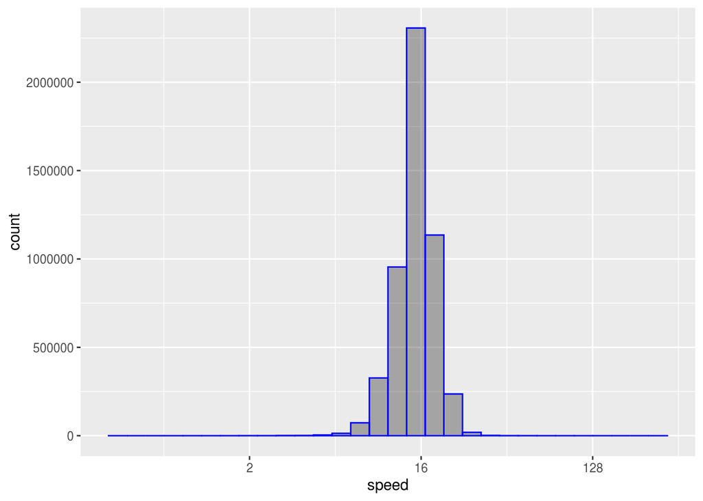

```r
expanded %>%
  ggplot(aes(speed)) +
  geom_histogram(xlab="Speed",
      fill=I("black"),
      col=I("blue"),
      alpha=I(.30)) + labs(x = "speed") + scale_x_continuous(trans = 'log2')
```

A velocidade das rotas se encontra, em sua maioria, na faixa dos 16 km/h.

Agora, faremos o histograma para a distância percorrida.

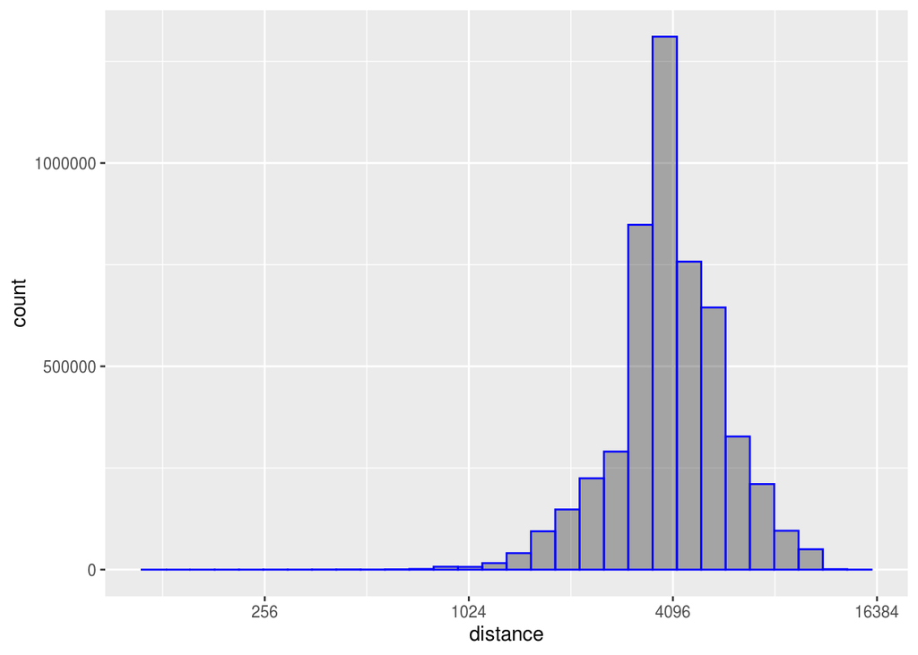

```r
expanded %>%
  ggplot(aes(dist_median)) +
  geom_histogram(xlab="Distance",
      fill=I("black"),
      col=I("blue"),
      alpha=I(.30)) + labs(x = "distance") + scale_x_continuous(trans = 'log2')
```

A distância percorrida se encontra, em sua maioria, na faixa de valores dos 4 km.

Histograma para a duração das viagens.

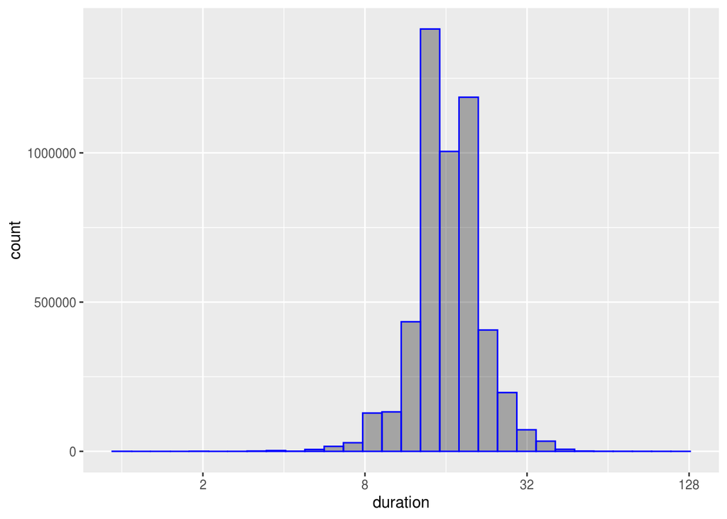

```r
expanded %>%
  ggplot(aes(duration_median)) +
  geom_histogram(xlab="Duration",
      fill=I("black"),
      col=I("blue"),
      alpha=I(.30)) + labs(x = "duration") + scale_x_continuous(trans = 'log2')
```

A duração das viagens se encontram, em sua maioria, na faixa de valores dos 16 minutos, sendo popular tanto nos valores um pouco abaixo quanto um pouco acima.

2. Agora analisaremos a real popularidade das rotas, para isso dividiremos a quantidade de viagens realizadas pela distância percorrida. É natural pensar que quanto maior é a distância percorrida mais pessoas realizam viagem na rota.

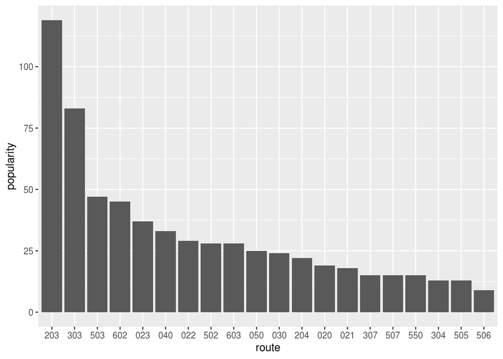

```r
estimated_trips_result %>%
  group_by(route) %>%
  summarise(popularity = divide_by_int(sum(quantity_trips), median(dist_median)), qntt = sum(quantity_trips)) %>%
  top_n(20) %>%
  ggplot(aes(x = reorder(route, -popularity), y = popularity)) + geom_col() + labs(x = "route")
```

```r
dat1 <- estimated_trips_result %>%
  group_by(route) %>%
  summarise(real_popularity = divide_by_int(sum(quantity_trips), median(dist_median)), qntt = sum(quantity_trips)) %>%
  top_n(14)
```

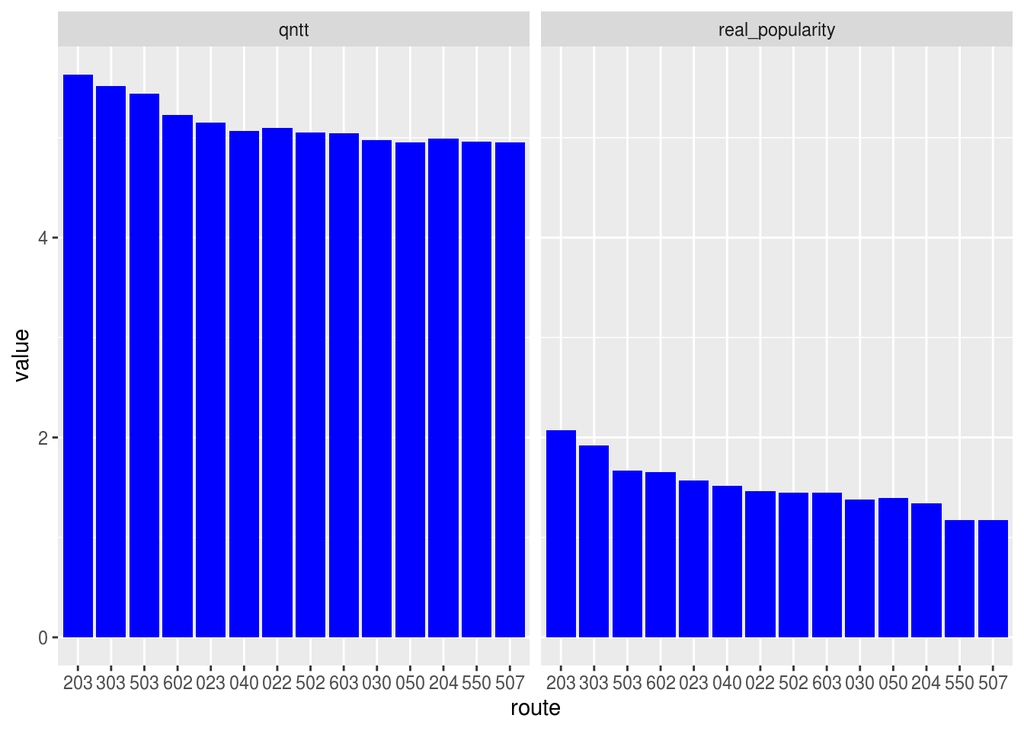

```r
data1long <- gather(dat1, key="measure", value="value", c("real_popularity", "qntt"))
data1long <- data1long %>% mutate(value_adjusted = log10(value))

ggplot(data1long, aes(x = reorder(route, -value_adjusted), y = value_adjusted)) + geom_col(stat='identity', fill="blue") + facet_wrap(~measure) + labs(x = "route", y = "value")
```

Levando em conta o ranking da popularidade puro e simples, ou seja, contando apenas a quantidade de viagens realizadas, algumas rotas apresentam comportamento diferente se levarmos em conta também a distância percorrida. Rotas como 505, 506 e 507 apresentam queda na popularidade quando dividimos sua quantidade de viagens por sua distância percorrida na mediana, pois a mesma é relativamente alta. As mesmas percorrem 5,738km, 8,810km, 5,804km, respectivamente. Vendo a natureza dessas rotas, observamos que percorrem bairros mais afastados do Centro da cidade, indo até o extremo sul e extremo sudeste do mapa. Por outro lado, as rotas que subiram nessa métrica foram a 050, 020 e 021, naturalmente apresentando distâncias mais curtas na mediana, com 3,513km, 3,901km e 3,967km, respectivamente. Um detalhe é que a rota 021 faz o mesmo percurso que a 022, só que em sentido antihorário.

3. Comparação entre a quantidade de viagens dos períodos de segunda e sexta e terça a quinta.

```r
day_group <- data.frame(week_day = c(2:6),
                        day_group = c("SS", "TQ", "TQ", "TQ", "SS"))

days <- estimated_trips_result %>%
  group_by(route, week_day) %>%
  summarise(qntt = sum(quantity_trips)) %>%
  merge(day_group) %>%
  group_by(day_group, route) %>%
  summarise(qntt = median(qntt))

segunda_sexta <- days %>%
  filter(day_group == "SS") %>%
  top_n(10)
terça_quinta <- days %>%
  filter(day_group == "TQ") %>%
  top_n(10)
```

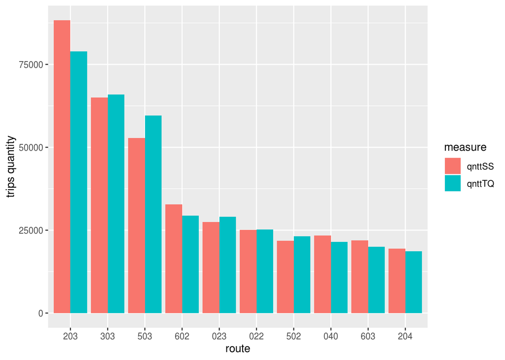

```r
data_comparation <- segunda_sexta %>%
  mutate(qnttSS = segunda_sexta$qntt, qnttTQ = terça_quinta$qntt)

comp_long <- gather(data_comparation, key="measure", value="value", c("qnttSS", "qnttTQ"))
comp_long <- comp_long %>% mutate(value_adjusted = value)

ggplot(comp_long, aes(fill = measure, x = reorder(route, -value_adjusted), y = value_adjusted)) + geom_col(position="dodge", stat='identity') + labs(x = "route", y = "trips quantity")
```

Como podemos ver, algumas rotas se destacam apresentando um número de viagens maior na mediana nos dias da semana de segunda e sexta em comparação com o período dos dias de terça a quinta, sendo elas a 203, 602 e 040. Por outro lado, rotas como 303, segunda mais popular no geral, 503 e 023 apresentam uma maior quantidade de viagens no período de terça a quinta.

4. Comparação da popularidade das rotas (levando em conta a quantidade de viagens) de acordo com os horários.

```r
hour_group <- data.frame(start_hour = c(4:23),
                         hour_group = c("I", "I", "M", "M", "M", "I", "I", "T", "T", "T", "I", "I", "I", "N", "N", "N", "I", "I", "I", "I"))

hours <- estimated_trips_result %>%
  group_by(route, start_hour) %>%
  summarise(qntt = sum(quantity_trips)) %>%
  merge(hour_group) %>%
  group_by(hour_group, route) %>%
  summarise(qntt = median(qntt))

seis_oito <- hours %>%
  filter(hour_group == "M") %>%
  top_n(12)
onze_uma <- hours %>%
  filter(hour_group == "T") %>%
  top_n(12)
cinco_sete <- hours %>%
  filter(hour_group == "N") %>%
  top_n(12)
```

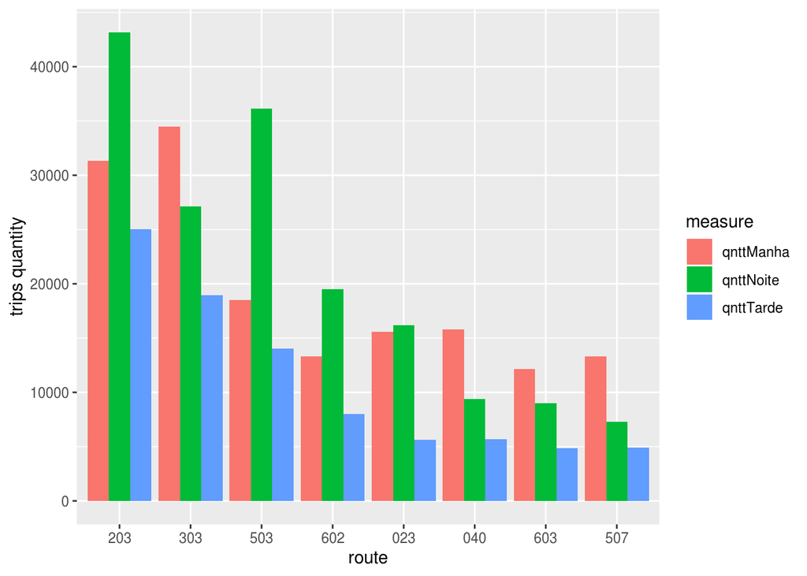

```r
data_comparation2 <- merge(x = seis_oito, y = onze_uma, by = "route")

data_comparation3 <- merge(x = data_comparation2, y = cinco_sete, by = "route")

data_comparation3 <- data_comparation3 %>% mutate(qnttManha = qntt.x, qnttTarde = qntt.y, qnttNoite = qntt)

comp_long1 <- gather(data_comparation3, key="measure", value="value", c("qnttManha", "qnttTarde", "qnttNoite"))
comp_long1 <- comp_long1 %>% mutate(value_adjusted = value)

ggplot(comp_long1, aes(fill = measure, x = reorder(route, -value_adjusted), y = value_adjusted)) + geom_col(position="dodge", stat='identity') + labs(x = "route", y = "trips quantity")
```

O horário denominado como “manhã” vai das 6h as 8h; como “tarde” das 11h as 13h e como “noite” das 17h as 19h.

Como podemos observar, pela manhã a rota 303 ultrapassa em quantidade de viagens a rota 203. A noite e a tarde a 203 volta a exercer robusta liderança. Observando também as rotas 203, 503, 602, 023 e 502 vemos que suas viagens são mais populares a noite. Por outro lado, as rotas 303, 022, 040, 030, 603, 507, 204 e as que se seguem são mais populares pela manhã, que é a faixa de horário mais popular durante todo o dia. Não vemos nenhuma rota sendo mais popular no horário da tarde, ou seja, aquela que se encontra entre as 11h e as 13h. Um destaque evidente fica por conta da rota 503, que dispara no horário da noite, ultrapassando a rota 303 e se aproximando da 203. A 503 é uma rota predominantemente noturna.

Vamos ver agora a distribuição da quantidade de viagens nos três principais horários do dia: 6-8, 11-13, 17-19.

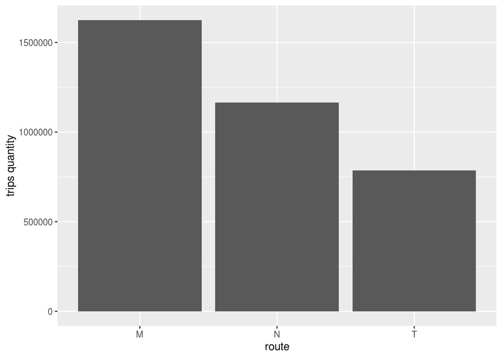

```r
hours <- estimated_trips_result %>%
  group_by(route, start_hour) %>%
  summarise(qntt = sum(quantity_trips)) %>%
  merge(hour_group) %>%
  group_by(hour_group) %>%
  summarise(qntt = sum(qntt))

hours <- hours %>% filter(hour_group != "I")

ggplot(hours, aes(x = reorder(hour_group, -qntt), y = qntt)) + geom_col(position="dodge", stat='identity') + labs(x = "route", y = "trips quantity")
```

Como vemos, o horário da manhã (das 6h as 8h) é o que concentra a maior quantidade de viagens feitas, seguido da noite (das 17h as 19h) e por fim da tarde (das 11h as 13h).

5. Iremos ver agora a distância percorrida pelas rotas nos três principais horários.

```r
hours2 <- estimated_trips_result %>%
  group_by(route, start_hour) %>%
  summarise(dist = median(dist_median)) %>%
  merge(hour_group) %>%
  group_by(hour_group, route) %>%
  summarise(dist = median(dist))

seis_oito2 <- hours2 %>%
  filter(hour_group == "M") %>%
  top_n(20)
onze_uma2 <- hours2 %>%
  filter(hour_group == "T") %>%
  top_n(20)
cinco_sete2 <- hours2 %>%
  filter(hour_group == "N") %>%
  top_n(20)
```

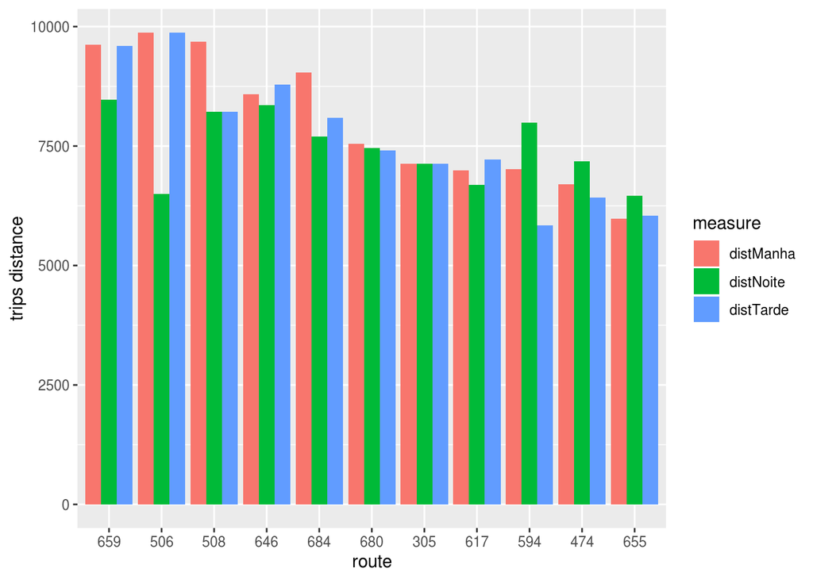

```r
data_comparation4 <- merge(x = seis_oito2, y = onze_uma2, by = "route")

data_comparation5 <- merge(x = data_comparation4, y = cinco_sete2, by = "route")

data_comparation5 <- data_comparation5 %>% mutate(distManha = dist.x, distTarde = dist.y, distNoite = dist)

comp_long1 <- gather(data_comparation5, key="measure", value="value", c("distManha", "distTarde", "distNoite"))

ggplot(comp_long1, aes(fill = measure, x = reorder(route, -value), y = value)) + geom_col(position="dodge", stat='identity') + labs(x = "route", y = "trips distance")
```

6. Observando agora para o tempo gasto.

```r
hours3 <- estimated_trips_result %>%
  group_by(route, start_hour) %>%
  summarise(duration = median(duration_median)) %>%
  merge(hour_group) %>%
  group_by(hour_group, route) %>%
  summarise(duration = median(duration))

seis_oito3 <- hours3 %>%
  filter(hour_group == "M") %>%
  top_n(20)
onze_uma3 <- hours3 %>%
  filter(hour_group == "T") %>%
  top_n(20)
cinco_sete3 <- hours3 %>%
  filter(hour_group == "N") %>%
  top_n(20)
```

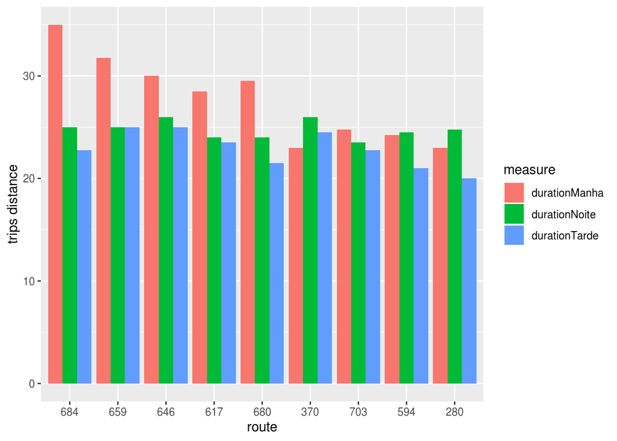

```r
data_comparation6 <- merge(x = seis_oito3, y = onze_uma3, by = "route")
data_comparation7 <- merge(x = data_comparation6, y = cinco_sete3, by = "route")

data_comparation7 <- data_comparation7 %>% mutate(durationManha = duration.x, durationTarde = duration.y, durationNoite = duration)

comp_long2 <- gather(data_comparation7, key="measure", value="value", c("durationManha", "durationTarde", "durationNoite"))

ggplot(comp_long2, aes(fill = measure, x = reorder(route, -value), y = value)) + geom_col(position="dodge", stat='identity') + labs(x = "route", y = "trips distance")
```

Como vemos, pela manhã as viagens são mais demoradas para a maioria das rotas (especificamente as 5 que possuem mediana mais alta). Interessante é que no horário da tarde (de 11h as 13h) todas as rotas, exceto a 370, fazem viagens menos demoradas em comparação com os outros dois horários. Podemos dizer, como possível razão para isso, que o fato de nos outros dois principais horários, manhã e noite, os passageiros irem para seus postos de trabalho e estudo e só voltem no fim do dia de forma definitiva para suas casas, no horário da tarde suas viagens são mais curtas.

7. 90 percentil do tempo de viagem

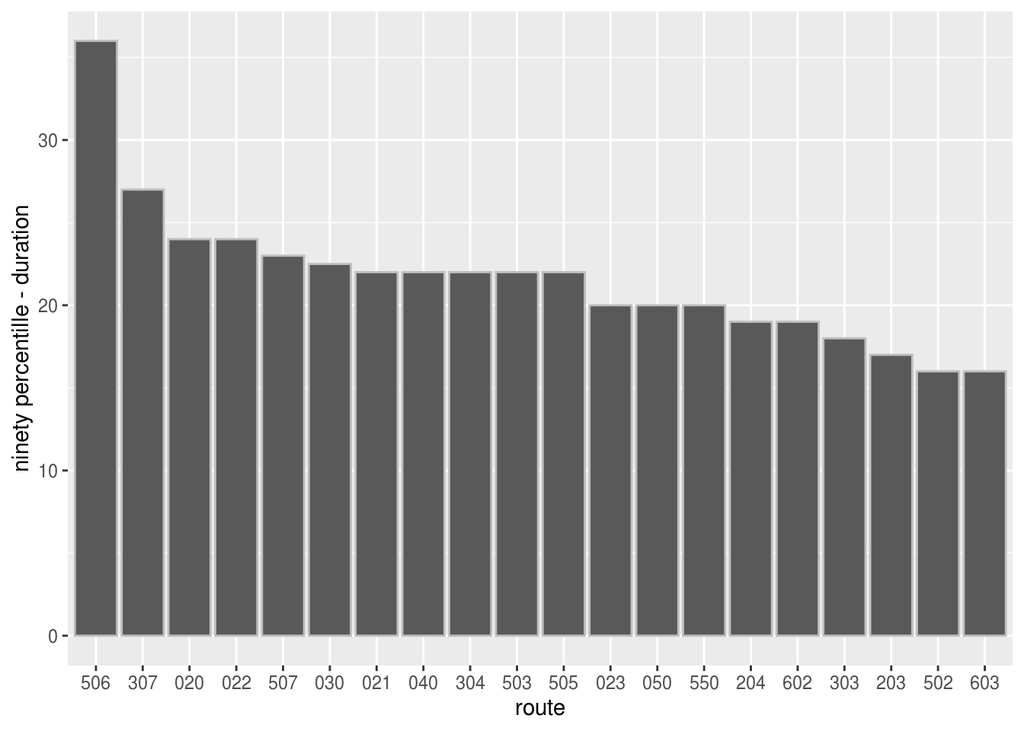

```r
estimated_trips_result %>%
  group_by(route) %>%
  summarise(ninety_perc = quantile(duration_median, probs = 0.9), qntt = sum(quantity_trips)) %>%
  filter(qntt > 300) %>%
  top_n(20) %>%
  ggplot(aes(x = reorder(route, -ninety_perc), y = ninety_perc)) + geom_col(stat='identity', colour = "gray") +
  labs(x = "route", y = "ninety percentille - duration")
```

8. 95 percentil do tempo de viagem

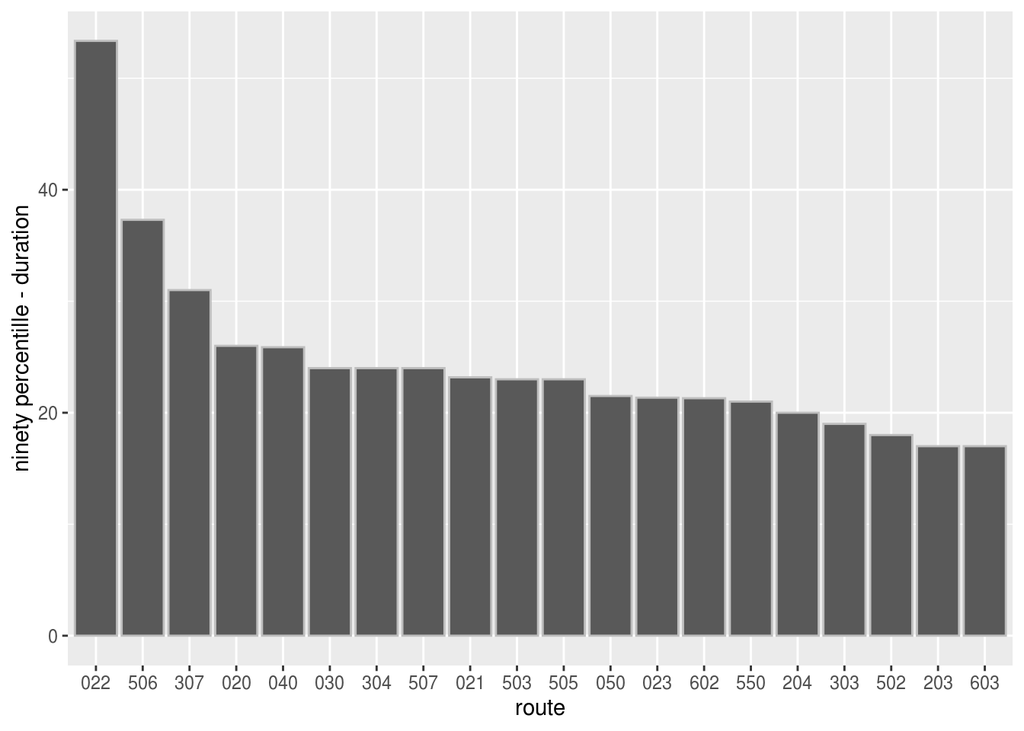

```r
estimated_trips_result %>%
  group_by(route) %>%
  summarise(ninety_perc = quantile(duration_median, probs = 0.95), qntt = sum(quantity_trips)) %>%
  filter(qntt > 300) %>%
  top_n(20) %>%
  ggplot(aes(x = reorder(route, -ninety_perc), y = ninety_perc)) + geom_col(stat='identity', colour = "gray") +
  labs(x = "route", y = "ninety percentille - duration")
```

Faremos agora a comparação entre o 90 e o 95 percentil no que diz respeito a duração das viagens. Observaremos em quais rotas os valores variam mais.

```r
dataPerc <- estimated_trips_result %>%
  group_by(route) %>%
  summarise(ninety_perc = quantile(duration_median, probs = 0.90), ninetyFive_perc = quantile(duration_median, probs = 0.95), qntt = sum(quantity_trips)) %>%
  filter(qntt > 300) %>%
  top_n(10)
```

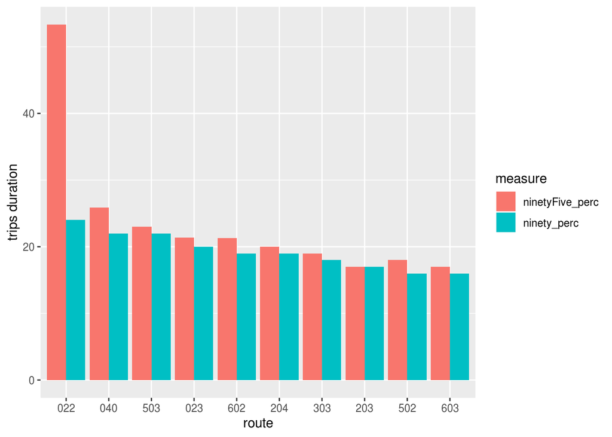

```r
dataPercLong <- gather(dataPerc, key="measure", value="value", c("ninety_perc", "ninetyFive_perc"))

ggplot(dataPercLong, aes(fill = measure, x = reorder(route, -value), y = value)) + geom_col(position="dodge", stat='identity') + labs(x = "route", y = "trips duration")
```

Medimos o 90 e o 95 percentil do tempo das viagens pelas rotas. Como podemos observar, a rota 022 varia bastante em seus tempos de viagens, seu 95 percentil mostra que 95% de suas viagens estão inclusas no intervalo de 0 a aproximadamente 50 minutos. O 90 percentil, por sua vez, nos mostra que as rotas não variam significativamente em seus tempos de viagens, estando inclusas no intervalo de 0 a pouco mais de 20 minutos.

9. Gráfico de dispersão para a diferença das viagens de segunda e sexta e terça a quinta. Popularidade, duração e distância.

Quantidade de viagens e distância.

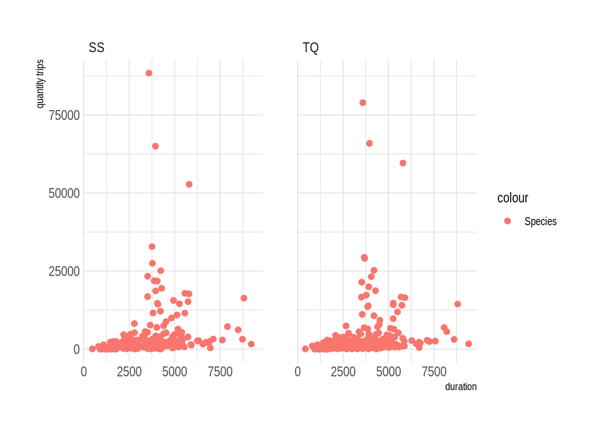

```r
days <- estimated_trips_result %>%
  group_by(route, week_day) %>%
  summarise(dist_median = median(dist_median), duration_median = median(duration_median), qntt = sum(quantity_trips)) %>%
  merge(day_group) %>%
  group_by(day_group, route) %>%
  summarise(dist_median = median(dist_median), duration_median = median(duration_median), qntt = median(qntt))

sp <- ggplot(days, aes(x = dist_median, y = qntt, color="Species")) +
    geom_point(size=2) +
    theme_ipsum()


sp + facet_grid(. ~ day_group)  + labs(x = "duration", y = "quantity trips")
```

Quantidade de viagens e duração

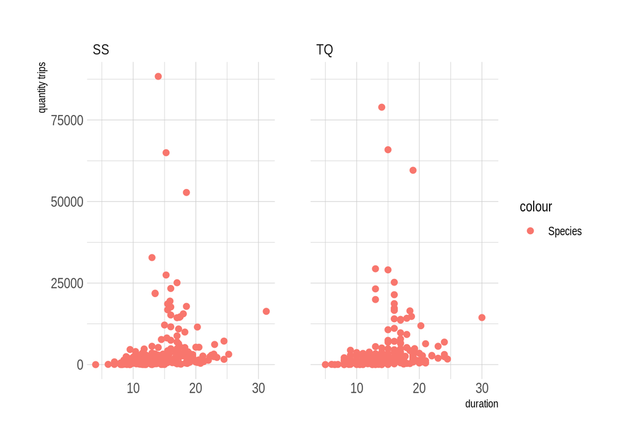

```r
sp <- ggplot(days, aes(x = duration_median, y = qntt, color="Species")) +
    geom_point(size=2) +
    theme_ipsum()

sp + facet_grid(. ~ day_group) + labs(x = "duration", y = "quantity trips")
```

Distância e duração

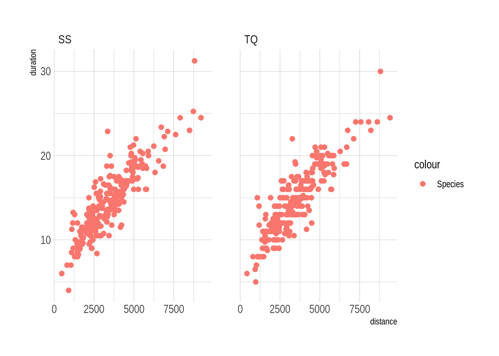

```r
sp <- ggplot(days, aes(x = dist_median, y = duration_median, color="Species")) +
    geom_point(size=2) +
    theme_ipsum()

sp + facet_grid(. ~ day_group) + labs(x = "distance", y = "duration")
```

Vemos que quanto maior é a distância percorrida em uma viagem maior é a sua duração.